# Heavy/Light Isotope-Based Serum Source Analysis — Execution Notebook

SerumSourceAnalyzer package

2026-09-01

# 1 Setup

This notebook reproduces the full Heavy/Light serum-source analysis pipeline implemented in the `SerumSourceAnalyzer` R package. It calls the main `run_serum_source_analysis()` orchestrator (with `render_notebook=FALSE` to avoid recursion) and then surfaces every intermediate object: console messages, input shapes, classification summaries, all ggplot figures and final output tables. The resulting HTML file is **self-contained** — open it directly in any modern browser to review the complete execution log.

```r
.libPaths(c(params$LIB_DIR, .libPaths()))
suppressPackageStartupMessages({
  library(SerumSourceAnalyzer)
  library(ggplot2)
  library(dplyr)
})
cat("SerumSourceAnalyzer version :", as.character(packageVersion("SerumSourceAnalyzer")), "\n")
```

```
SerumSourceAnalyzer version : 0.1.0
```

```r
cat("Output directory            :", params$OUTPUT_DIR, "\n")
```

```
Output directory            : F:/WYF/NP_1/Serum_source_analysis_notebook_run
```

```r
cat("Input workbook              :", basename(params$INPUT_FILE), "\n")
```

```
Input workbook              : MaxQuant_annotated_with_total.xlsx
```

# 2 Parameters

The user-visible parameter object from `serum_source_params()` and the sample-to-column mapping used for this run.

```r
input_file  <- params$INPUT_FILE
output_dir  <- params$OUTPUT_DIR
params_obj  <- if (inherits(params$PARAMS, "serum_source_params")) {
  params$PARAMS
} else {
  do.call(serum_source_params, params$PARAMS)
}
sample_info <- if (is.null(params$SAMPLE_INFO)) build_sample_info() else params$SAMPLE_INFO

print(params_obj)
```

```
$min_valid_reps
[1] 2

$min_absolute_light_excess
[1] 0.05

$background_multiplier_high
[1] 3

$background_multiplier_medium
[1] 2

$min_support_reps_when_three_valid
[1] 2

$min_support_reps_when_two_valid
[1] 2

$max_serum_fraction_cv_high_confidence
[1] 0.5

$minimum_fraction_sd_floor
[1] 0.02

$min_light_dominance_ratio
[1] 0.7

$eps
[1] 1e-12

attr(,"class")
[1] "serum_source_params"
```

```r
cat("\nGroups to analyse:", paste(unique(sample_info$group), collapse = ", "), "\n")
```

```
Groups to analyse: UCEV, DGEV_PC_1-3, DGEV_PC_10-12, DGEV_PC_4-9, UCEVPC
```

## 2.1 Sample ↔︎ MaxQuant column mapping

```r
knitr::kable(
  as.data.frame(sample_info)[, c("sample_id", "group",
                                 "light_column", "heavy_column",
                                 "peptide_column")],
  row.names = FALSE,
  caption = "Sample mapping (en-dash MaxQuant column names)"
)
```

Sample mapping (en-dash MaxQuant column names)

[output not shown]

# 3 Step 1 — Run the complete pipeline

All reading, preparation, classification, source correction, output saving, plot generation and Markdown-report writing happens in this one call. We set `render_notebook = FALSE` here because **this** Rmd is the notebook itself; recursion would otherwise loop forever.

```r
start_time <- Sys.time()
pipeline_res <- run_serum_source_analysis(
  input_file      = input_file,
  output_dir      = output_dir,
  sample_info     = sample_info,
  params          = params_obj,
  save_outputs    = TRUE,
  make_plots      = TRUE,
  write_report    = TRUE,
  render_notebook = FALSE
)
```

```
Reading input file...
```

```
Input dimensions: 5298 rows x 116 columns
```

```
Starting serum-source analysis for all groups...
```

```
--> Processing: DGEV_PC_1-3_vs_UCEV
```

```
--> Processing: DGEV_PC_10-12_vs_UCEV
```

```
--> Processing: DGEV_PC_4-9_vs_UCEV
```

```
--> Processing: UCEVPC_vs_UCEV
```

```r
elapsed <- round(difftime(Sys.time(), start_time, units = "secs"), 1)
cat("Pipeline finished in", as.numeric(elapsed), "seconds.\n")
```

```
Pipeline finished in 59.1 seconds.
```

# 4 Step 2 — Input & preparation

```r
cat("Annotated proteins (rows)           :",
    formatC(nrow(pipeline_res$annotation), format = "d", big.mark = ","), "\n")
```

```
Annotated proteins (rows)           : 5,298
```

```r
cat("Per-protein / per-replicate rows    :",
    formatC(nrow(pipeline_res$lh_long), format = "d", big.mark = ","), "\n")
```

```
Per-protein / per-replicate rows    : 79,470
```

```r
cat("UCEV proteins (SD estimate base)    :",
    formatC(length(unique(pipeline_res$ucev_sd$Protein_Row_ID)),
            format = "d", big.mark = ","), "\n")
```

```
UCEV proteins (SD estimate base)    : 804
```

```r
cat("Global Light-fraction SD floor      :",
    signif(pipeline_res$global_fraction_sd_floor, 4), "\n")
```

```
Global Light-fraction SD floor      : 0.02
```

## 4.1 First 6 proteins × first 8 annotation columns

```r
knitr::kable(
  utils::head(as.data.frame(pipeline_res$annotation), 6)[, seq_len(min(8, ncol(pipeline_res$annotation)))],
  row.names = FALSE,
  caption = "Head of protein annotation table"
)
```

Head of protein annotation table

| Protein_Row_ID | Original_Excel_Row | Protein_IDs | Representative_ID | Protein_names | Gene_names | In_house_db | Plasma_Altas_db |
| --- | --- | --- | --- | --- | --- | --- | --- |
| Q9C0C9;K7ES11;K7EQ12 | 1 | Q9C0C9;K7ES11;K7EQ12 | Q9C0C9 | (E3-independent) E2 ubiquitin-conjugating enzyme | UBE2O | No | No |
| B4E139;P52849;B4DVV6;B4DE98;B4DU70;S4R438 | 2 | B4E139;P52849;B4DVV6;B4DE98;B4DU70;S4R438 | B4E139 | [heparan sulfate]-glucosamine N-sulfotransferase | NDST2 | No | No |
| Q75MP9;Q75MQ0;S4S3R8;A0A090N8E9;Q15910 | 3 | Q75MP9;Q75MQ0;S4S3R8;A0A090N8E9;Q15910 | Q75MP9 | [histone H3]-lysine(27) N-trimethyltransferase | EZH2 | No | No |
| S4R3N1;A8K012;Q9Y3A3;B4DM50 | 4 | S4R3N1;A8K012;Q9Y3A3;B4DM50 | S4R3N1 | 10 kDa heat shock protein, mitochondrial | HSPE1-MOB4 | Yes | Yes |
| B3KX19;Q6IBM8;Q15029;Q8IXJ3;A8KAP3;B4DZB1;B3KWY2;K7EP67;K7EJ74;K7EIT3 | 5 | B3KX19;Q6IBM8;Q15029;Q8IXJ3;A8KAP3;B4DZB1;B3KWY2;K7EP67;K7EJ74;K7EIT3 | B3KX19 | 116 kDa U5 small nuclear ribonucleoprotein component | U5-116KD | No | Yes |
| V9HWC4;Q9NRX4;Q6FIE5;Q9P019 | 6 | V9HWC4;Q9NRX4;Q6FIE5;Q9P019 | V9HWC4 | 14 kDa phosphohistidine phosphatase | HEL-S-132P | No | Yes |

## 4.2 Head of per-replicate Heavy/Light table

```r
knitr::kable(
  utils::head(as.data.frame(pipeline_res$lh_long), 8),
  row.names = FALSE,
  caption = "Head of the long-format Heavy/Light table"
)
```

Head of the long-format Heavy/Light table

| Protein_Row_ID | sample_id | group | Light_raw | Heavy_raw | Peptides_raw | Paired_LH_Valid_Rep | Target_L_Dominant_Rep | Both_channels_zero_or_na | High_Pep_Matched_Rep | Single_Pep_Matched_Rep | High_Pep_L_Dominant_Rep | Single_Pep_L_Dominant_Rep | Light | Heavy | Total_Light_Heavy | Light_fraction | Original_Excel_Row | Protein_IDs | Representative_ID | Protein_names | Gene_names | In_house_db | Plasma_Altas_db | In_house_serum_annotation | Human_plasma_PeptideAtlas_annotation | Database_evidence |
| --- | --- | --- | --- | --- | --- | --- | --- | --- | --- | --- | --- | --- | --- | --- | --- | --- | --- | --- | --- | --- | --- | --- | --- | --- | --- | --- |
| Q9C0C9;K7ES11;K7EQ12 | UCEV_1 | UCEV | 0.0 | 402760 | 4 | FALSE | FALSE | FALSE | FALSE | FALSE | FALSE | FALSE | NA | NA | NA | NA | 1 | Q9C0C9;K7ES11;K7EQ12 | Q9C0C9 | (E3-independent) E2 ubiquitin-conjugating enzyme | UBE2O | No | No | No | No | In-house serum database + Human Plasma PeptideAtlas |
| B4E139;P52849;B4DVV6;B4DE98;B4DU70;S4R438 | UCEV_1 | UCEV | 0.0 | 0 | 0 | FALSE | FALSE | TRUE | FALSE | FALSE | FALSE | FALSE | NA | NA | NA | NA | 2 | B4E139;P52849;B4DVV6;B4DE98;B4DU70;S4R438 | B4E139 | [heparan sulfate]-glucosamine N-sulfotransferase | NDST2 | No | No | No | No | In-house serum database + Human Plasma PeptideAtlas |
| Q75MP9;Q75MQ0;S4S3R8;A0A090N8E9;Q15910 | UCEV_1 | UCEV | 0.0 | 0 | 0 | FALSE | FALSE | TRUE | FALSE | FALSE | FALSE | FALSE | NA | NA | NA | NA | 3 | Q75MP9;Q75MQ0;S4S3R8;A0A090N8E9;Q15910 | Q75MP9 | [histone H3]-lysine(27) N-trimethyltransferase | EZH2 | No | No | No | No | In-house serum database + Human Plasma PeptideAtlas |
| S4R3N1;A8K012;Q9Y3A3;B4DM50 | UCEV_1 | UCEV | 0.0 | 180180 | 1 | FALSE | FALSE | FALSE | FALSE | FALSE | FALSE | FALSE | NA | NA | NA | NA | 4 | S4R3N1;A8K012;Q9Y3A3;B4DM50 | S4R3N1 | 10 kDa heat shock protein, mitochondrial | HSPE1-MOB4 | Yes | Yes | Yes | Yes | In-house serum database + Human Plasma PeptideAtlas |
| B3KX19;Q6IBM8;Q15029;Q8IXJ3;A8KAP3;B4DZB1;B3KWY2;K7EP67;K7EJ74;K7EIT3 | UCEV_1 | UCEV | 0.0 | 5333400 | 19 | FALSE | FALSE | FALSE | FALSE | FALSE | FALSE | FALSE | NA | NA | NA | NA | 5 | B3KX19;Q6IBM8;Q15029;Q8IXJ3;A8KAP3;B4DZB1;B3KWY2;K7EP67;K7EJ74;K7EIT3 | B3KX19 | 116 kDa U5 small nuclear ribonucleoprotein component | U5-116KD | No | Yes | No | Yes | In-house serum database + Human Plasma PeptideAtlas |
| V9HWC4;Q9NRX4;Q6FIE5;Q9P019 | UCEV_1 | UCEV | 0.0 | 145420 | 1 | FALSE | FALSE | FALSE | FALSE | FALSE | FALSE | FALSE | NA | NA | NA | NA | 6 | V9HWC4;Q9NRX4;Q6FIE5;Q9P019 | V9HWC4 | 14 kDa phosphohistidine phosphatase | HEL-S-132P | No | Yes | No | Yes | In-house serum database + Human Plasma PeptideAtlas |
| V9HWD6;P31946;B5BU24;Q4VY20;Q4VY19;A0A0J9YWE8;Q59EQ2;A0A0J9YWZ2 | UCEV_1 | UCEV | 64843.0 | 4758800 | 3 | TRUE | FALSE | FALSE | TRUE | FALSE | FALSE | FALSE | 64843.0 | 4758800 | 4823643 | 0.0134427 | 7 | V9HWD6;P31946;B5BU24;Q4VY20;Q4VY19;A0A0J9YWE8;Q59EQ2;A0A0J9YWZ2 | V9HWD6 | 14-3-3 protein beta/alpha | HEL-S-1 | No | Yes | No | Yes | In-house serum database + Human Plasma PeptideAtlas |
| V9HW98;P62258;G9K389;G9K388;B4DJB0;B4DJF2;I3L3T1;B7ZA86;K7EM20;K7EIT4;I3L0W5;B3KT37 | UCEV_1 | UCEV | 7479.9 | 39793000 | 18 | TRUE | FALSE | FALSE | TRUE | FALSE | FALSE | FALSE | 7479.9 | 39793000 | 39800480 | 0.0001879 | 8 | V9HW98;P62258;G9K389;G9K388;B4DJB0;B4DJF2;I3L3T1;B7ZA86;K7EM20;K7EIT4;I3L0W5;B3KT37 | V9HW98 | 14-3-3 protein epsilon | HEL2 | Yes | Yes | Yes | Yes | In-house serum database + Human Plasma PeptideAtlas |

# 5 Step 3 — Classification summary

Wide-format counts of each classification bucket per comparison group.

```r
cs <- as.data.frame(pipeline_res$case_summary)
cs$protein_count <- as.integer(cs$protein_count)
wide <- reshape(
  cs[, c("comparison", "classification", "protein_count")],
  idvar     = "comparison",
  timevar   = "classification",
  direction = "wide"
)
names(wide) <- sub("^protein_count\\.", "", names(wide))
wide <- wide[order(wide$comparison), ]
for (cc in setdiff(names(wide), "comparison")) {
  wide[[cc]][is.na(wide[[cc]])] <- 0L
}
knitr::kable(wide, row.names = FALSE,
             caption = "Classification counts per comparison (wide)")
```

Classification counts per comparison (wide)

| comparison | Ambiguous | Source-corrected, high confidence | Source-corrected, single-peptide strong candidate | Acquired-only (Level 1) | Acquired-only (Level 2) | Control_absent_other | Control_missing | Target_group_missing | Likely_residual | Source-corrected, medium confidence | Source-corrected, single-peptide candidate |
| --- | --- | --- | --- | --- | --- | --- | --- | --- | --- | --- | --- |
| DGEV_PC_1-3_vs_UCEV | 1 | 1 | 2 | 5 | 15 | 1264 | 3210 | 795 | 0 | 0 | 0 |
| DGEV_PC_10-12_vs_UCEV | 110 | 14 | 5 | 49 | 224 | 1011 | 3210 | 537 | 64 | 22 | 3 |
| DGEV_PC_4-9_vs_UCEV | 118 | 11 | 2 | 14 | 29 | 1241 | 3210 | 493 | 110 | 24 | 1 |
| UCEVPC_vs_UCEV | 237 | 4 | 1 | 45 | 62 | 1177 | 3210 | 277 | 204 | 16 | 3 |

## 5.1 Primary serum-derived protein counts

```r
prim_count <- pipeline_res$primary_serum %>%
  dplyr::count(comparison, name = "Primary_serum_proteins")
knitr::kable(as.data.frame(prim_count), row.names = FALSE)
```

| comparison | Primary_serum_proteins |
| --- | --- |
| DGEV_PC_1-3_vs_UCEV | 21 |
| DGEV_PC_10-12_vs_UCEV | 309 |
| DGEV_PC_4-9_vs_UCEV | 78 |
| UCEVPC_vs_UCEV | 127 |

## 5.2 Case breakdown by comparison and assigned case

```r
knitr::kable(as.data.frame(pipeline_res$case_summary),
             row.names = FALSE,
             caption = "Full case × classification breakdown")
```

Full case × classification breakdown

| comparison | assigned_case | classification | protein_count |
| --- | --- | --- | --- |
| DGEV_PC_1-3_vs_UCEV | Case 1 | Ambiguous | 1 |
| DGEV_PC_1-3_vs_UCEV | Case 1 | Source-corrected, high confidence | 1 |
| DGEV_PC_1-3_vs_UCEV | Case 2 | Source-corrected, single-peptide strong candidate | 2 |
| DGEV_PC_1-3_vs_UCEV | Case 3 | Acquired-only (Level 1) | 5 |
| DGEV_PC_1-3_vs_UCEV | Case 4 | Acquired-only (Level 2) | 15 |
| DGEV_PC_1-3_vs_UCEV | Other / Unassigned | Ambiguous | 5 |
| DGEV_PC_1-3_vs_UCEV | Other / Unassigned | Control_absent_other | 1264 |
| DGEV_PC_1-3_vs_UCEV | Other / Unassigned | Control_missing | 3210 |
| DGEV_PC_1-3_vs_UCEV | Other / Unassigned | Target_group_missing | 795 |
| DGEV_PC_10-12_vs_UCEV | Case 1 | Ambiguous | 110 |
| DGEV_PC_10-12_vs_UCEV | Case 1 | Likely_residual | 64 |
| DGEV_PC_10-12_vs_UCEV | Case 1 | Source-corrected, high confidence | 14 |
| DGEV_PC_10-12_vs_UCEV | Case 1 | Source-corrected, medium confidence | 22 |
| DGEV_PC_10-12_vs_UCEV | Case 2 | Ambiguous | 22 |
| DGEV_PC_10-12_vs_UCEV | Case 2 | Likely_residual | 5 |
| DGEV_PC_10-12_vs_UCEV | Case 2 | Source-corrected, single-peptide candidate | 3 |
| DGEV_PC_10-12_vs_UCEV | Case 2 | Source-corrected, single-peptide strong candidate | 5 |
| DGEV_PC_10-12_vs_UCEV | Case 3 | Acquired-only (Level 1) | 49 |
| DGEV_PC_10-12_vs_UCEV | Case 4 | Acquired-only (Level 2) | 224 |
| DGEV_PC_10-12_vs_UCEV | Other / Unassigned | Ambiguous | 17 |
| DGEV_PC_10-12_vs_UCEV | Other / Unassigned | Control_absent_other | 1011 |
| DGEV_PC_10-12_vs_UCEV | Other / Unassigned | Control_missing | 3210 |
| DGEV_PC_10-12_vs_UCEV | Other / Unassigned | Likely_residual | 5 |
| DGEV_PC_10-12_vs_UCEV | Other / Unassigned | Target_group_missing | 537 |
| DGEV_PC_4-9_vs_UCEV | Case 1 | Ambiguous | 118 |
| DGEV_PC_4-9_vs_UCEV | Case 1 | Likely_residual | 110 |
| DGEV_PC_4-9_vs_UCEV | Case 1 | Source-corrected, high confidence | 11 |
| DGEV_PC_4-9_vs_UCEV | Case 1 | Source-corrected, medium confidence | 24 |
| DGEV_PC_4-9_vs_UCEV | Case 2 | Ambiguous | 16 |
| DGEV_PC_4-9_vs_UCEV | Case 2 | Likely_residual | 8 |
| DGEV_PC_4-9_vs_UCEV | Case 2 | Source-corrected, single-peptide candidate | 1 |
| DGEV_PC_4-9_vs_UCEV | Case 2 | Source-corrected, single-peptide strong candidate | 2 |
| DGEV_PC_4-9_vs_UCEV | Case 3 | Acquired-only (Level 1) | 14 |
| DGEV_PC_4-9_vs_UCEV | Case 4 | Acquired-only (Level 2) | 29 |
| DGEV_PC_4-9_vs_UCEV | Other / Unassigned | Ambiguous | 14 |
| DGEV_PC_4-9_vs_UCEV | Other / Unassigned | Control_absent_other | 1241 |
| DGEV_PC_4-9_vs_UCEV | Other / Unassigned | Control_missing | 3210 |
| DGEV_PC_4-9_vs_UCEV | Other / Unassigned | Likely_residual | 7 |
| DGEV_PC_4-9_vs_UCEV | Other / Unassigned | Target_group_missing | 493 |
| UCEVPC_vs_UCEV | Case 1 | Ambiguous | 237 |
| UCEVPC_vs_UCEV | Case 1 | Likely_residual | 204 |
| UCEVPC_vs_UCEV | Case 1 | Source-corrected, high confidence | 4 |
| UCEVPC_vs_UCEV | Case 1 | Source-corrected, medium confidence | 16 |
| UCEVPC_vs_UCEV | Case 2 | Ambiguous | 21 |
| UCEVPC_vs_UCEV | Case 2 | Likely_residual | 11 |
| UCEVPC_vs_UCEV | Case 2 | Source-corrected, single-peptide candidate | 3 |
| UCEVPC_vs_UCEV | Case 2 | Source-corrected, single-peptide strong candidate | 1 |
| UCEVPC_vs_UCEV | Case 3 | Acquired-only (Level 1) | 45 |
| UCEVPC_vs_UCEV | Case 4 | Acquired-only (Level 2) | 62 |
| UCEVPC_vs_UCEV | Other / Unassigned | Ambiguous | 18 |
| UCEVPC_vs_UCEV | Other / Unassigned | Control_absent_other | 1177 |
| UCEVPC_vs_UCEV | Other / Unassigned | Control_missing | 3210 |
| UCEVPC_vs_UCEV | Other / Unassigned | Likely_residual | 12 |
| UCEVPC_vs_UCEV | Other / Unassigned | Target_group_missing | 277 |

# 6 Step 4 — Visualisations

Every ggplot object produced by the pipeline is redrawn below so you can inspect them directly in the notebook. PNG copies of all these plots also live under `plots/` inside the output directory.

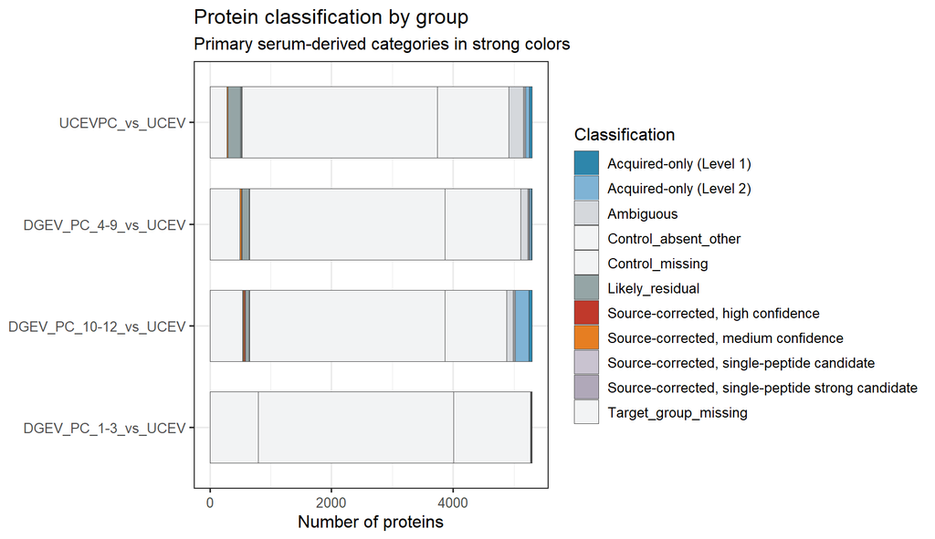

```r
pipeline_res$plots$classification_summary
```

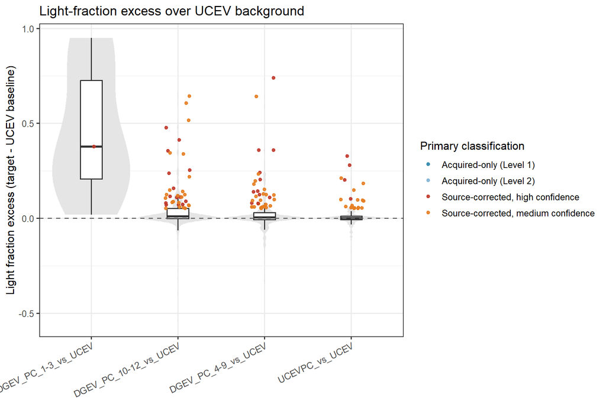

```r
pipeline_res$plots$excess_distribution
```

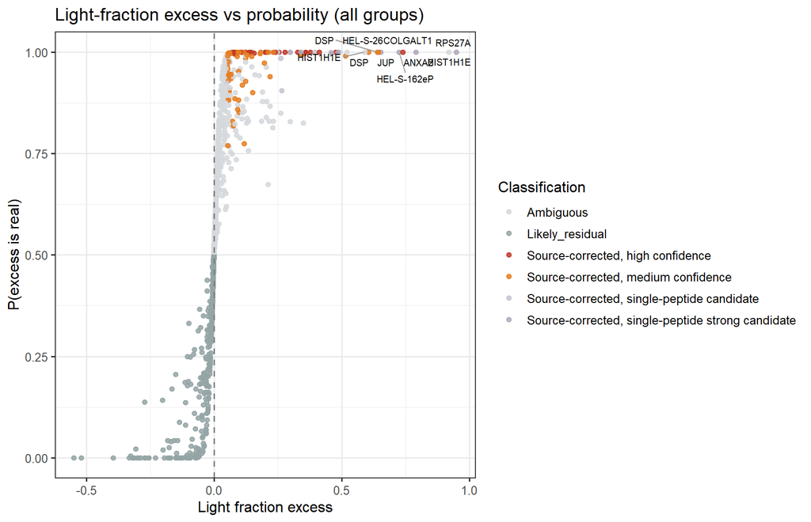

```r
pipeline_res$plots$excess_vs_probability
```

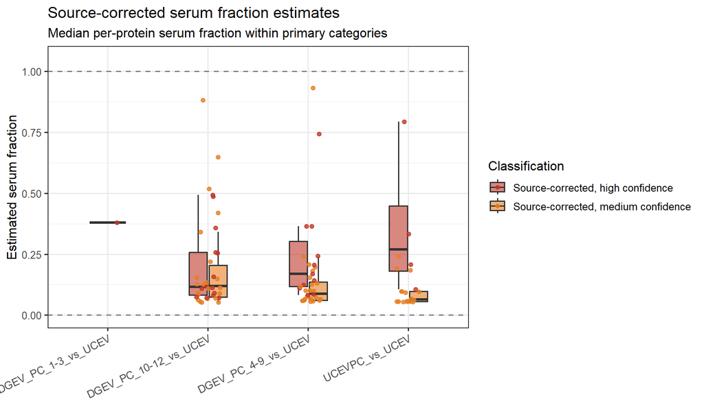

```r
pipeline_res$plots$serum_fraction
```

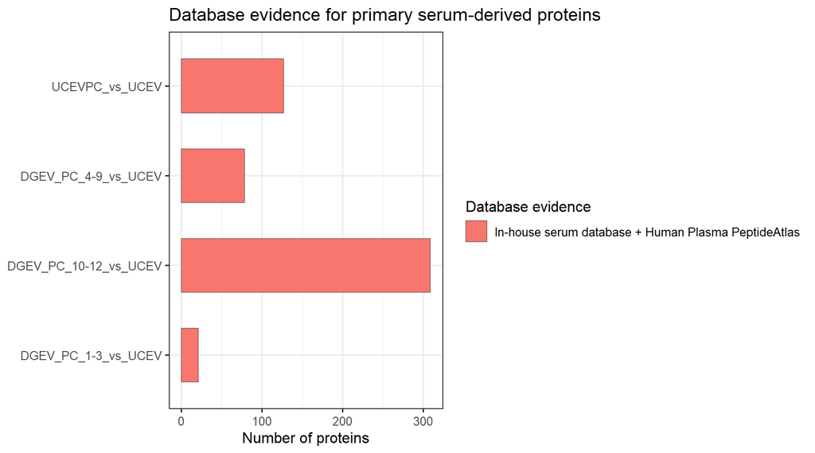

```r
pipeline_res$plots$database_evidence
```

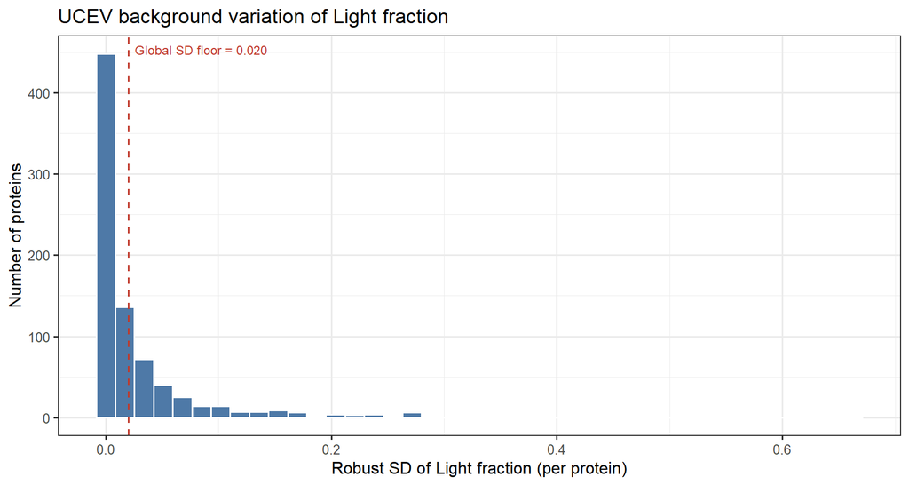

```r
pipeline_res$plots$ucev_background
```

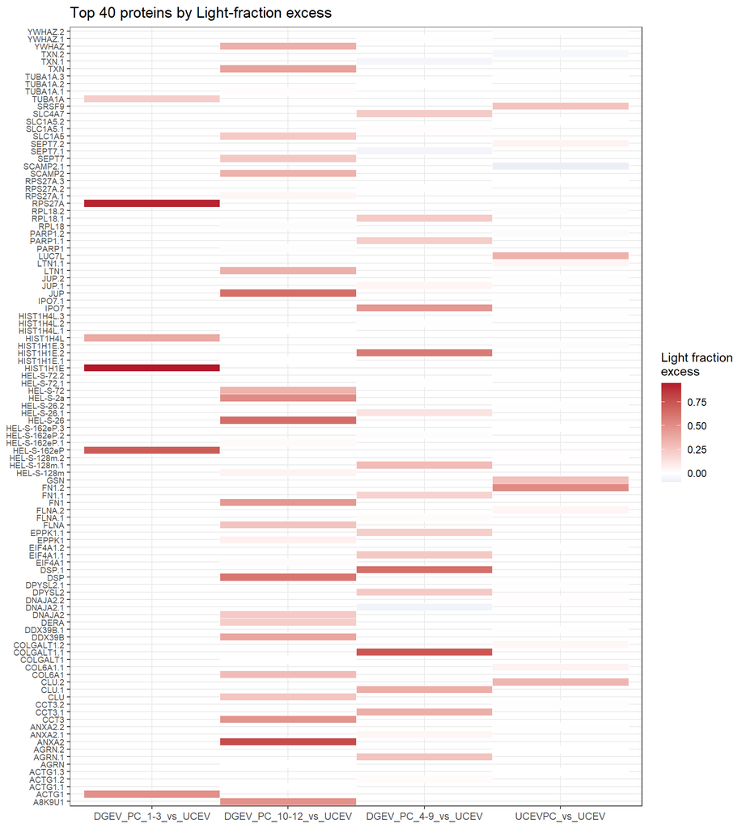

```r
pipeline_res$plots$excess_heatmap
```

# 7 Step 5 — Database evidence for primary serum proteins

```r
knitr::kable(
  as.data.frame(pipeline_res$database_summary),
  row.names = FALSE,
  caption = "Protein counts split by comparison × classification × database evidence"
)
```

Protein counts split by comparison × classification × database evidence

| comparison | Database_evidence | classification | protein_count |
| --- | --- | --- | --- |
| DGEV_PC_1-3_vs_UCEV | In-house serum database + Human Plasma PeptideAtlas | Acquired-only (Level 1) | 5 |
| DGEV_PC_1-3_vs_UCEV | In-house serum database + Human Plasma PeptideAtlas | Acquired-only (Level 2) | 15 |
| DGEV_PC_1-3_vs_UCEV | In-house serum database + Human Plasma PeptideAtlas | Ambiguous | 6 |
| DGEV_PC_1-3_vs_UCEV | In-house serum database + Human Plasma PeptideAtlas | Control_absent_other | 1264 |
| DGEV_PC_1-3_vs_UCEV | In-house serum database + Human Plasma PeptideAtlas | Control_missing | 3210 |
| DGEV_PC_1-3_vs_UCEV | In-house serum database + Human Plasma PeptideAtlas | Source-corrected, high confidence | 1 |
| DGEV_PC_1-3_vs_UCEV | In-house serum database + Human Plasma PeptideAtlas | Source-corrected, single-peptide strong candidate | 2 |
| DGEV_PC_1-3_vs_UCEV | In-house serum database + Human Plasma PeptideAtlas | Target_group_missing | 795 |
| DGEV_PC_10-12_vs_UCEV | In-house serum database + Human Plasma PeptideAtlas | Acquired-only (Level 1) | 49 |
| DGEV_PC_10-12_vs_UCEV | In-house serum database + Human Plasma PeptideAtlas | Acquired-only (Level 2) | 224 |
| DGEV_PC_10-12_vs_UCEV | In-house serum database + Human Plasma PeptideAtlas | Ambiguous | 149 |
| DGEV_PC_10-12_vs_UCEV | In-house serum database + Human Plasma PeptideAtlas | Control_absent_other | 1011 |
| DGEV_PC_10-12_vs_UCEV | In-house serum database + Human Plasma PeptideAtlas | Control_missing | 3210 |
| DGEV_PC_10-12_vs_UCEV | In-house serum database + Human Plasma PeptideAtlas | Likely_residual | 74 |
| DGEV_PC_10-12_vs_UCEV | In-house serum database + Human Plasma PeptideAtlas | Source-corrected, high confidence | 14 |
| DGEV_PC_10-12_vs_UCEV | In-house serum database + Human Plasma PeptideAtlas | Source-corrected, medium confidence | 22 |
| DGEV_PC_10-12_vs_UCEV | In-house serum database + Human Plasma PeptideAtlas | Source-corrected, single-peptide candidate | 3 |
| DGEV_PC_10-12_vs_UCEV | In-house serum database + Human Plasma PeptideAtlas | Source-corrected, single-peptide strong candidate | 5 |
| DGEV_PC_10-12_vs_UCEV | In-house serum database + Human Plasma PeptideAtlas | Target_group_missing | 537 |
| DGEV_PC_4-9_vs_UCEV | In-house serum database + Human Plasma PeptideAtlas | Acquired-only (Level 1) | 14 |
| DGEV_PC_4-9_vs_UCEV | In-house serum database + Human Plasma PeptideAtlas | Acquired-only (Level 2) | 29 |
| DGEV_PC_4-9_vs_UCEV | In-house serum database + Human Plasma PeptideAtlas | Ambiguous | 148 |
| DGEV_PC_4-9_vs_UCEV | In-house serum database + Human Plasma PeptideAtlas | Control_absent_other | 1241 |
| DGEV_PC_4-9_vs_UCEV | In-house serum database + Human Plasma PeptideAtlas | Control_missing | 3210 |
| DGEV_PC_4-9_vs_UCEV | In-house serum database + Human Plasma PeptideAtlas | Likely_residual | 125 |
| DGEV_PC_4-9_vs_UCEV | In-house serum database + Human Plasma PeptideAtlas | Source-corrected, high confidence | 11 |
| DGEV_PC_4-9_vs_UCEV | In-house serum database + Human Plasma PeptideAtlas | Source-corrected, medium confidence | 24 |
| DGEV_PC_4-9_vs_UCEV | In-house serum database + Human Plasma PeptideAtlas | Source-corrected, single-peptide candidate | 1 |
| DGEV_PC_4-9_vs_UCEV | In-house serum database + Human Plasma PeptideAtlas | Source-corrected, single-peptide strong candidate | 2 |
| DGEV_PC_4-9_vs_UCEV | In-house serum database + Human Plasma PeptideAtlas | Target_group_missing | 493 |
| UCEVPC_vs_UCEV | In-house serum database + Human Plasma PeptideAtlas | Acquired-only (Level 1) | 45 |
| UCEVPC_vs_UCEV | In-house serum database + Human Plasma PeptideAtlas | Acquired-only (Level 2) | 62 |
| UCEVPC_vs_UCEV | In-house serum database + Human Plasma PeptideAtlas | Ambiguous | 276 |
| UCEVPC_vs_UCEV | In-house serum database + Human Plasma PeptideAtlas | Control_absent_other | 1177 |
| UCEVPC_vs_UCEV | In-house serum database + Human Plasma PeptideAtlas | Control_missing | 3210 |
| UCEVPC_vs_UCEV | In-house serum database + Human Plasma PeptideAtlas | Likely_residual | 227 |
| UCEVPC_vs_UCEV | In-house serum database + Human Plasma PeptideAtlas | Source-corrected, high confidence | 4 |
| UCEVPC_vs_UCEV | In-house serum database + Human Plasma PeptideAtlas | Source-corrected, medium confidence | 16 |
| UCEVPC_vs_UCEV | In-house serum database + Human Plasma PeptideAtlas | Source-corrected, single-peptide candidate | 3 |
| UCEVPC_vs_UCEV | In-house serum database + Human Plasma PeptideAtlas | Source-corrected, single-peptide strong candidate | 1 |
| UCEVPC_vs_UCEV | In-house serum database + Human Plasma PeptideAtlas | Target_group_missing | 277 |

# 8 Step 6 — Top 10 serum candidates per group

```r
top10 <- pipeline_res$primary_serum %>%
  dplyr::group_by(comparison) %>%
  dplyr::arrange(dplyr::desc(Light_fraction_excess), .by_group = TRUE) %>%
  dplyr::slice_head(n = 10) %>%
  dplyr::ungroup() %>%
  dplyr::transmute(
    Group           = comparison,
    Gene            = Gene_names,
    Protein         = substr(Protein_IDs, 1, 40),
    Classification  = classification,
    `Light excess`  = round(Light_fraction_excess, 3),
    `Serum fraction`= round(estimated_serum_fraction, 3),
    `CV (serum fr.)`= round(serum_fraction_CV, 3),
    `Database`      = Database_evidence
  )
knitr::kable(as.data.frame(top10), row.names = FALSE,
             caption = "Top 10 serum-derived candidates per comparison group, ranked by Light-fraction excess")
```

Top 10 serum-derived candidates per comparison group, ranked by Light-fraction excess

| Group | Gene | Protein | Classification | Light excess | Serum fraction | CV (serum fr.) | Database |
| --- | --- | --- | --- | --- | --- | --- | --- |
| DGEV_PC_1-3_vs_UCEV | HIST1H4L | B2R4R0;P62805;Q0VAS5;Q6B823 | Source-corrected, high confidence | 0.377 | 0.380 | 0.261 | In-house serum database + Human Plasma PeptideAtlas |
| DGEV_PC_1-3_vs_UCEV | APOH | D9IWP9;A0A384NKM6;P02749;B4DPN0;J3KS17;J | Acquired-only (Level 2) | NA | NA | NA | In-house serum database + Human Plasma PeptideAtlas |
| DGEV_PC_1-3_vs_UCEV | EmGFP-LacZ-E2F-TdTom | A0A679KTH4 | Acquired-only (Level 2) | NA | NA | NA | In-house serum database + Human Plasma PeptideAtlas |
| DGEV_PC_1-3_vs_UCEV | CASP14 | P31944;B2CIS9;A9UFC0 | Acquired-only (Level 1) | NA | NA | NA | In-house serum database + Human Plasma PeptideAtlas |
| DGEV_PC_1-3_vs_UCEV | COL1A1 | P02452;Q6LAN8;H9C5C5;Q9UMA6;T1RTD8;B7Z4S | Acquired-only (Level 2) | NA | NA | NA | In-house serum database + Human Plasma PeptideAtlas |
| DGEV_PC_1-3_vs_UCEV | COL1A2 | A0A0S2Z3H5;A0A384MDU2;P08123 | Acquired-only (Level 1) | NA | NA | NA | In-house serum database + Human Plasma PeptideAtlas |
| DGEV_PC_1-3_vs_UCEV | DCD | P81605 | Acquired-only (Level 1) | NA | NA | NA | In-house serum database + Human Plasma PeptideAtlas |
| DGEV_PC_1-3_vs_UCEV | FLG | I0B0K5;I0B0K6;I0B0K7;I0B0K8;CON__P20930; | Acquired-only (Level 2) | NA | NA | NA | In-house serum database + Human Plasma PeptideAtlas |
| DGEV_PC_1-3_vs_UCEV | LGALS7 | P47929 | Acquired-only (Level 2) | NA | NA | NA | In-house serum database + Human Plasma PeptideAtlas |
| DGEV_PC_1-3_vs_UCEV | HP | P00738;J3QR68;H0Y300;A0A0C4DGL8;J3QLC9;Q | Acquired-only (Level 2) | NA | NA | NA | In-house serum database + Human Plasma PeptideAtlas |
| DGEV_PC_10-12_vs_UCEV | JUP | A0A0S2Z487;P14923;A0A0S2Z495;Q7KZ86 | Source-corrected, medium confidence | 0.643 | 0.648 | 0.521 | In-house serum database + Human Plasma PeptideAtlas |
| DGEV_PC_10-12_vs_UCEV | DSP | P15924;A0AAQ5BH40;A0AAQ5BH53;Q4LE79;A0AA | Source-corrected, medium confidence | 0.606 | 0.881 | 0.072 | In-house serum database + Human Plasma PeptideAtlas |
| DGEV_PC_10-12_vs_UCEV | HEL-S-2a | V9HW12;P32119;B4DF70;A6NIW5 | Source-corrected, medium confidence | 0.515 | 0.517 | 0.573 | In-house serum database + Human Plasma PeptideAtlas |
| DGEV_PC_10-12_vs_UCEV | CCT3 | B3KX11;P49368;Q2TU64;Q59H77;B4DUR8;E9PRC | Source-corrected, high confidence | 0.477 | 0.486 | 0.146 | In-house serum database + Human Plasma PeptideAtlas |
| DGEV_PC_10-12_vs_UCEV | TXN | H9ZYJ2;P10599 | Source-corrected, high confidence | 0.413 | 0.493 | 0.486 | In-house serum database + Human Plasma PeptideAtlas |
| DGEV_PC_10-12_vs_UCEV | YWHAZ | D0PNI1;P63104;E7EX29;B0AZS6;E7ESK7;B7Z2E | Source-corrected, high confidence | 0.354 | 0.358 | 0.499 | In-house serum database + Human Plasma PeptideAtlas |
| DGEV_PC_10-12_vs_UCEV | SCAMP2 | Q6IBK3;A8K769;A0A140VK92;O15127;H3BV04;H | Source-corrected, medium confidence | 0.344 | 0.419 | 0.528 | In-house serum database + Human Plasma PeptideAtlas |
| DGEV_PC_10-12_vs_UCEV | HEL-S-72 | B4DJ51;B2RDW0;P0DP25;P0DP24;P0DP23;Q9BRL | Source-corrected, medium confidence | 0.338 | 0.340 | 0.524 | In-house serum database + Human Plasma PeptideAtlas |
| DGEV_PC_10-12_vs_UCEV | CLU | A0A384NKS6;P10909;H0YC35;H0YLK8;E7ERK6;B | Source-corrected, high confidence | 0.254 | 0.258 | 0.112 | In-house serum database + Human Plasma PeptideAtlas |
| DGEV_PC_10-12_vs_UCEV | DNAJA2 | O60884;T2DN57;T2DPK5;A0A087WT48;I3L320 | Source-corrected, high confidence | 0.236 | 0.254 | 0.324 | In-house serum database + Human Plasma PeptideAtlas |
| DGEV_PC_4-9_vs_UCEV | COLGALT1 | Q8NBJ5;M0QX72;Q6IPW8;A0A8I5QKL8;A0A8I5QL | Source-corrected, high confidence | 0.739 | 0.743 | 0.287 | In-house serum database + Human Plasma PeptideAtlas |
| DGEV_PC_4-9_vs_UCEV | DSP | P15924;A0AAQ5BH40;A0AAQ5BH53;Q4LE79;A0AA | Source-corrected, medium confidence | 0.640 | 0.931 | 0.097 | In-house serum database + Human Plasma PeptideAtlas |
| DGEV_PC_4-9_vs_UCEV | CLU | A0A384NKS6;P10909;H0YC35;H0YLK8;E7ERK6;B | Source-corrected, high confidence | 0.359 | 0.365 | 0.066 | In-house serum database + Human Plasma PeptideAtlas |
| DGEV_PC_4-9_vs_UCEV | CCT3 | B3KX11;P49368;Q2TU64;Q59H77;B4DUR8;E9PRC | Source-corrected, high confidence | 0.358 | 0.365 | 0.158 | In-house serum database + Human Plasma PeptideAtlas |
| DGEV_PC_4-9_vs_UCEV | EIF4A1 | P60842;A8K7F6;A8K088;J3KT12;Q59F68;J3QS6 | Source-corrected, high confidence | 0.240 | 0.242 | 0.306 | In-house serum database + Human Plasma PeptideAtlas |
| DGEV_PC_4-9_vs_UCEV | RPL18 | J3QQ67;Q07020;Q0QEW2;G3V203;H0YHA7;F8VYV | Source-corrected, medium confidence | 0.233 | 0.239 | 0.708 | In-house serum database + Human Plasma PeptideAtlas |
| DGEV_PC_4-9_vs_UCEV | TAGLN2 | A0A384MTL2;P37802;X6RJP6;B7Z5A2;C9J5W6;Q | Source-corrected, high confidence | 0.204 | 0.205 | 0.436 | In-house serum database + Human Plasma PeptideAtlas |
| DGEV_PC_4-9_vs_UCEV | FABP5 | E7DVW5;Q01469;I6L8B7;A8MUU1 | Source-corrected, medium confidence | 0.196 | 0.208 | 0.699 | In-house serum database + Human Plasma PeptideAtlas |
| DGEV_PC_4-9_vs_UCEV | SLC1A3 | A0A087X0U3;Q8N169;A0A7P0TAG7;P43003;B4DH | Source-corrected, medium confidence | 0.180 | 0.181 | 0.580 | In-house serum database + Human Plasma PeptideAtlas |
| DGEV_PC_4-9_vs_UCEV | BLMH | Q13867;K7ESE8;B4DXF3;K7ES02;J3KSD8;J3KS7 | Source-corrected, medium confidence | 0.151 | 0.155 | 0.949 | In-house serum database + Human Plasma PeptideAtlas |
| UCEVPC_vs_UCEV | CLU | A0A384NKS6;P10909;H0YC35;H0YLK8;E7ERK6;B | Source-corrected, high confidence | 0.327 | 0.332 | 0.113 | In-house serum database + Human Plasma PeptideAtlas |
| UCEVPC_vs_UCEV | GSN | B7Z2X4;B7Z992;A0A0A0MS51;B7Z9A0;A0A8V8TN | Source-corrected, high confidence | 0.279 | 0.793 | 0.433 | In-house serum database + Human Plasma PeptideAtlas |
| UCEVPC_vs_UCEV | WDR1 | Q59ER5;Q53GN4;O75083;Q53H17;A0A8V8TNT7;V | Source-corrected, medium confidence | 0.212 | 0.240 | 0.868 | In-house serum database + Human Plasma PeptideAtlas |
| UCEVPC_vs_UCEV | EHD1 | B2R5U3;A0A024R571;Q9H4M9;B4DTR4;B4DZH9;B | Source-corrected, high confidence | 0.201 | 0.207 | 0.391 | In-house serum database + Human Plasma PeptideAtlas |
| UCEVPC_vs_UCEV | PSMA5 | P28066;A0A109NGN6;Q5U0A0 | Source-corrected, medium confidence | 0.183 | 0.185 | 0.703 | In-house serum database + Human Plasma PeptideAtlas |
| UCEVPC_vs_UCEV | DDX5 | P17844;B5BUE6;J3KTA4;B4DN41;B4DNG2;A0A0G | Source-corrected, medium confidence | 0.148 | 0.191 | 0.453 | In-house serum database + Human Plasma PeptideAtlas |
| UCEVPC_vs_UCEV | DOCK7 | Q96N67;A0A2X0SSK2;A0A1B0GWE0;B4DSH0;A0A1 | Source-corrected, high confidence | 0.102 | 0.105 | 0.145 | In-house serum database + Human Plasma PeptideAtlas |
| UCEVPC_vs_UCEV | MAPK3 | E9PJF0;L7RXH5;P27361;E9PQW4;Q8NHX0;Q7Z3H | Source-corrected, medium confidence | 0.098 | 0.098 | 0.868 | In-house serum database + Human Plasma PeptideAtlas |
| UCEVPC_vs_UCEV | BYSL | Q13895;F8WBL2;H7BY94 | Source-corrected, medium confidence | 0.096 | 0.097 | 1.058 | In-house serum database + Human Plasma PeptideAtlas |
| UCEVPC_vs_UCEV | ATP6V1A | P38606;A0A994J738;B7Z2V6;A0A994J477;C9JA | Source-corrected, medium confidence | 0.095 | 0.096 | 0.868 | In-house serum database + Human Plasma PeptideAtlas |

# 9 Step 7 — Outputs written to disk

The following files were written inside the output directory. All paths are relative to `params$OUTPUT_DIR`.

```r
files <- list.files(output_dir, recursive = FALSE, all.files = FALSE,
                    include.dirs = FALSE)
dirs  <- list.dirs(output_dir, recursive = FALSE, full.names = FALSE)
info  <- data.frame(
  Name     = c(files, dirs),
  Type     = c(rep("file",     length(files)),
               rep("directory", length(dirs))),
  `Size KB`= c(round(file.size(file.path(output_dir, files)) / 1024, 1),
               rep(NA_real_, length(dirs))),
  check.names = FALSE,
  stringsAsFactors = FALSE
)
info <- info[order(info$Type, info$Name), ]
knitr::kable(info, row.names = FALSE,
             caption = "Top-level files produced by the pipeline run")
```

Top-level files produced by the pipeline run

| Name | Type | Size KB |
| --- | --- | --- |
| analysis_notebook_files | directory | NA |
| DGEV_PC_1-3_vs_UCEV | directory | NA |
| DGEV_PC_10-12_vs_UCEV | directory | NA |
| DGEV_PC_4-9_vs_UCEV | directory | NA |
| plots | directory | NA |
| UCEVPC_vs_UCEV | directory | NA |
| 00_All_Comparisons_Merged_Results.csv | file | 9789.5 |
| 00_All_Comparisons_Primary_Serum_Derived_Merged.csv | file | 279.4 |
| 00_Classification_Summary_by_Group.csv | file | 3.4 |
| 00_Database_Annotation_Summary_All_Groups.csv | file | 4.4 |
| 01_sample_information.csv | file | 1.8 |
| 02_protein_database_annotation.csv | file | 1429.1 |
| 04_UCEV_background_variation.csv | file | 104.9 |
| analysis_notebook_files | file | 0.0 |
| Analysis_Report.md | file | 10.9 |
| DGEV_PC_1-3_vs_UCEV | file | 4.0 |
| DGEV_PC_1-3_vs_UCEV_Primary_Serum_Proteins_with_Database_Annotation.csv | file | 10.8 |
| DGEV_PC_10-12_vs_UCEV | file | 4.0 |
| DGEV_PC_10-12_vs_UCEV_Primary_Serum_Proteins_with_Database_Annotation.csv | file | 157.6 |
| DGEV_PC_4-9_vs_UCEV | file | 4.0 |
| DGEV_PC_4-9_vs_UCEV_Primary_Serum_Proteins_with_Database_Annotation.csv | file | 47.2 |
| plots | file | 4.0 |
| Serum_Source_Analysis_All_Groups_Summary.xlsx | file | 684.7 |
| UCEVPC_vs_UCEV | file | 4.0 |
| UCEVPC_vs_UCEV_Primary_Serum_Proteins_with_Database_Annotation.csv | file | 70.9 |

## 9.1 Location of the Markdown summary report

The plain-Markdown summary report (short version, no code log) is at:

```r
rep_md <- file.path(output_dir, "Analysis_Report.md")
cat("* **Markdown summary** : `", rep_md, "` (",
    ifelse(file.exists(rep_md), paste(round(file.size(rep_md) / 1024, 1), "KB"), "missing"),
    ")\n", sep = "")
```

- **Markdown summary** : `F:/WYF/NP_1/Serum_source_analysis_notebook_run/Analysis_Report.md` (10.9 KB)

Total wall-clock time for this notebook run: **59.1 seconds**.